# Introduction to R - R Ladies Vienna

Pia Pfeiffer

2024-02-15

## What is R? https://www.r-project.org/

> R is a programming language and software environment specifically designed for statistical computing and graphics. It provides a wide variety of statistical and graphical techniques, making it a preferred tool for data analysis and visualization among statisticians, data scientists, researchers, and analysts […] across various industries and domains.
- Firms like Google, Pfizer, Bank of America, Amazon and Microsoft use R for their statistical analyses.
- R is open source! freely available for anyone to use, modify, and distribute, active community

### Statistics

- Most classical statistics and much of the latest methodology is available for use with R
- A few of these are built into the base R environment, but many are supplied as packages available through the CRAN family of Internet sites (via https://CRAN.R-project.org)
- Visualization: publication-quality plots and charts
- Reproducibility: R promotes reproducible research by enabling users to document their analyses in a script format.

## Getting Started

### Installation

- Downloading and installing R. https://cran.r-project.org/
- Downloading and installing RStudio. https://posit.co/downloads/

### RStudio

- RStudio is an integrated development environment (IDE) for R.
- It includes a console, syntax-highlighting editor that supports direct code execution, as well as tools for plotting, history, debugging and workspace management.
- RStudio is available in open source and commercial editions.
- RStudio runs on the desktop (Windows, Mac, and Linux) or in a browser connected to RStudio Server or RStudio Server Pro (Debian/Ubuntu, RedHat/CentOS, and SUSE Linux).
- Introduction to RStudio interface.

## Before we begin

### Getting help

R is a collaborative project with many contributors. Type ‘contributors()’ for more information and ‘citation()’ on how to cite R or R packages in publications. Type ‘demo()’ for some demos, ‘help()’ or ‘?’ for on-line help, or ‘help.start()’ for an HTML browser interface to help. Type ‘q()’ to quit R.

- Beginner’s guide: https://support.posit.co/hc/en-us/articles/201141096-Getting-Started-with-R
- Manual: https://cran.r-project.org/doc/manuals/r-release/R-intro.pdf
- R Cookbook: https://rc2e.com/
- R for Data Science: https://r4ds.hadley.nz/

### Basic commands and arithmetic operations.

- Using R as a calculator

```r
3 + 4
```

```
## [1] 7
```

```r
3 - 7
```

```
## [1] -4
```

```r
2 * 20
```

```
## [1] 40
```

```r
4/2
```

```
## [1] 2
```

```r
10^3
```

```
## [1] 1000
```

```r
sqrt(10)
```

```
## [1] 3.162278
```

- Comparisons

```r
3 < 5
```

```
## [1] TRUE
```

```r
3 > 5
```

```
## [1] FALSE
```

```r
3 <= 5
```

```
## [1] TRUE
```

```r
3 >= 5
```

```
## [1] FALSE
```

```r
3 == 5     # Attention: double equal sign
```

```
## [1] FALSE
```

```r
3 != 5
```

```
## [1] TRUE
```

### Variables and data types.

- Assignment

```r
x <- 3
y = 4
5 -> z # works, but not recommended
```

## Data Structures

Creating and manipulating data structures.

- Atomic vectors (elements are same type)

```r
pyth_triple <- c(x, y, z)
?c
# indexing
pyth_triple[pyth_triple >= 4]
```

```
## [1] 4 5
```

- Factors (for categorical data, can be ordered, levels are unique values)

```r
x1 <- c("Dec", "Apr", "Jan", "Mar")
x2 <- c("Dec", "Apr", "Jam", "Mar")
sort(x1)
```

```
## [1] "Apr" "Dec" "Jan" "Mar"
```

```r
month_levels <- c(
  "Jan", "Feb", "Mar", "Apr", "May", "Jun",
  "Jul", "Aug", "Sep", "Oct", "Nov", "Dec"
)
y1 <- factor(x1, levels = month_levels)
y2 <- factor(x2, levels = month_levels)
sort(y1)
```

```
## [1] Jan Mar Apr Dec
## Levels: Jan Feb Mar Apr May Jun Jul Aug Sep Oct Nov Dec
```

- Sequences (generate regular sequences)

```r
seq_incr <- seq(1, 5, by = 1)
seq_decr <- 10^seq(4, 0, by = -1)
```

- Matrices (2-dimensional generalization of vectors)

```r
mat <- matrix(0, nrow = 5, ncol = 5)
diag(mat) <- c(rep(1, 2), rep(4, 3))
```

- Data Frames (matrix-like structures, can handle different data types)

```r
v_char <- paste0("char", seq(1, 10, 1))
v_num <- seq(0.01, 0.1, length.out = 10)
v_bool <- c(rep(TRUE, 4), rep(FALSE, 6))
df <- data.frame(col1 = v_char,
                 col2 = v_num,
                 col3 = v_bool)
df$col1[df$col3] #indexing
```

```
## [1] "char1" "char2" "char3" "char4"
```

```r
df$col2[df$col2 > 0.05]
```

```
## [1] 0.05 0.06 0.07 0.08 0.09 0.10
```

- Lists (general form of vector, elements can be of different type)

```r
my_list <- list(matrix = mat,
                vector = pyth_triple,
                fact = y2,
                bool = TRUE)
```

## Packages

- CRAN: https://cran.r-project.org/
- Bioconductor: https://www.bioconductor.org/
- find packages that might be useful for your field: https://cran.r-project.org/web/views/
- popular packages for Data Science are combined in ‘tidyverse’ https://www.tidyverse.org/
- Installation (CRAN / Github)

```r
install.packages("tidyverse")
remotes::install_github("tidyverse/tidyverse")
```

- get help with packages and functions

```r
library(tidyverse)
citation("tidyverse")
```

```
##
##   Wickham H, Averick M, Bryan J, Chang W, McGowan LD, François R,
##   Grolemund G, Hayes A, Henry L, Hester J, Kuhn M, Pedersen TL, Miller
##   E, Bache SM, Müller K, Ooms J, Robinson D, Seidel DP, Spinu V,
##   Takahashi K, Vaughan D, Wilke C, Woo K, Yutani H (2019). "Welcome to
##   the tidyverse." _Journal of Open Source Software_, *4*(43), 1686.
##   doi:10.21105/joss.01686 <https://doi.org/10.21105/joss.01686>.
##
## A BibTeX entry for LaTeX users is
##
##   @Article{,
##     title = {Welcome to the {tidyverse}},
##     author = {Hadley Wickham and Mara Averick and Jennifer Bryan and Winston Chang and Lucy D'Agostino McGowan and Romain François and Garrett Grolemund and Alex Hayes and Lionel Henry and Jim Hester and Max Kuhn and Thomas Lin Pedersen and Evan Miller and Stephan Milton Bache and Kirill Müller a…
##     year = {2019},
##     journal = {Journal of Open Source Software},
##     volume = {4},
##     number = {43},
##     pages = {1686},
##     doi = {10.21105/joss.01686},
##   }
```

```r
help(package = "tidyverse")
```

## Data Import and Export

- Importing data from CSV, Excel, text files.

```r
?read.table

path1 <- file.path("cereal", "cereal_1.txt")
path2 <- file.path("cereal", "cereal_2.txt")
path3 <- file.path("cereal", "cereal_3.csv")
path4 <- file.path("cereal", "cereal_4.csv")

cereal1 <- read.table(path1, header = T)
cereal2 <- read.table(path2)
cereal3 <- read.csv(path3, header = T)
cereal4 <- read.csv2(path4, header = T)

head(cereal1) # look at data
```

```
##   Sodium.mg. Sugar.g. Type
## 1          0     11,4    A
## 2        340     18,9    A
## 3         70      6,1    A
## 4        140     14,7    C
## 5        200     13,1    C
## 6        180      1,4    C
```

- Data cleaning and preprocessing.
- Useful package ‘janitor’: https://cran.r-project.org/web/packages/janitor/index.html

```r
cereal_new <- cereal2[,2:4]
colnames(cereal_new) <- c("Sodium", "Sugar", "Type")

cereal_new[5,2] <- NA
mean(cereal_new[,2])
```

```
## [1] NA
```

```r
cereal_new <- na.omit(cereal_new)
mean(cereal_new[,2])
```

```
## [1] 9.084211
```

```r
cereal_new$Desc <- paste(cereal_new$Sugar, cereal_new$Type)
```

- Exporting data.

```r
?write.table

write.csv(cereal_new, file = file.path("cereal", "cereal_mod.csv"))

save(cereal_new, file = file.path("cereal", "cereal_mod.Rdata"))
load(file = file.path("cereal", "cereal_mod.Rdata"))
```

- package for data wrangling: dplyr https://dplyr.tidyverse.org/

## Data Visualization

- Creating and modifying plots with base R bar plots, histograms.

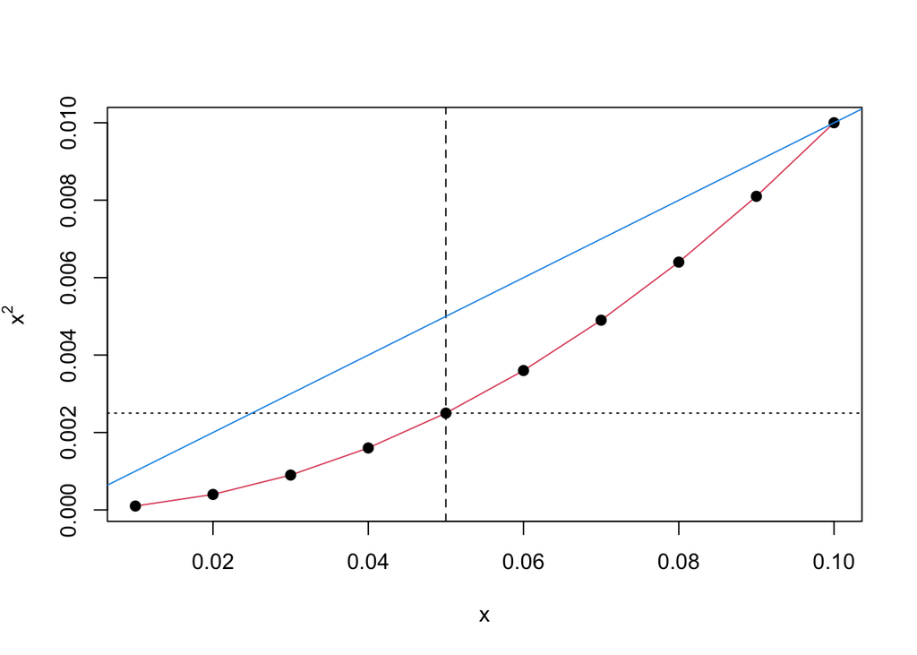

```r
plot(df$col2, df$col2^2,
     type = "l",
     lty = 1,
     col = 2,
     xlab = "x", ylab = expression(x^2))
points(df$col2, df$col2^2,
       pch = 19)
abline(v = 0.05, lty = 2)
abline(h = 0.0025, lty = 3)
abline(coef = c(0, 0.1), col = 4)
```

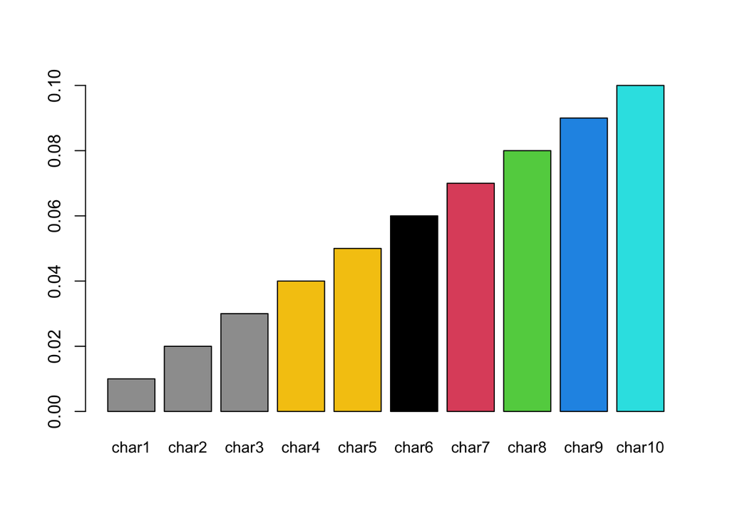

```r
barplot(df$col2,
        names.arg = df$col1,
        cex.names = 0.9,
        col = c(rep(8, 3), rep(7, 2), 1:5))
```

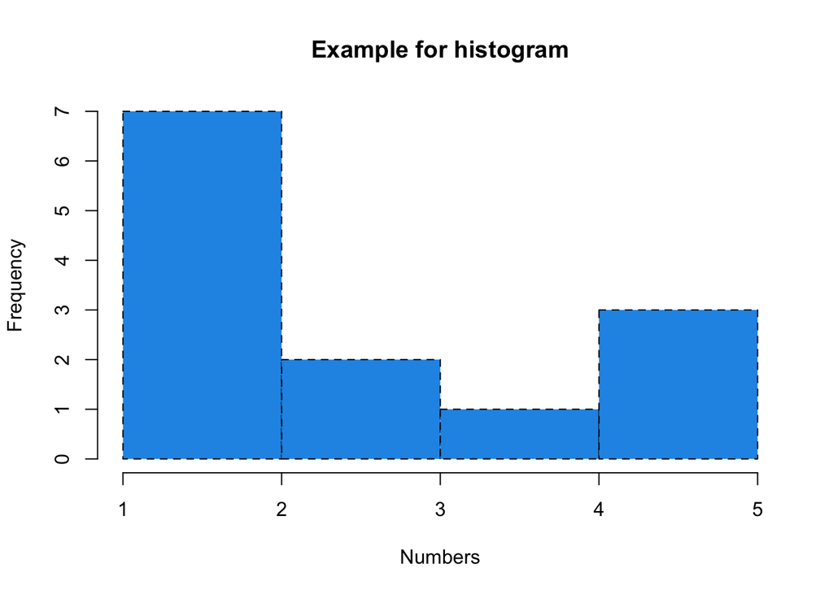

```r
hist(c(1, 1, 1, 1, 2, 3, 2, 2, 3, 4, 5, 5, 5),
     breaks = 4,
     main = "Example for histogram",
     xlab = "Numbers",
     col = 4, lty = 2)
```

- multivariate: pairs

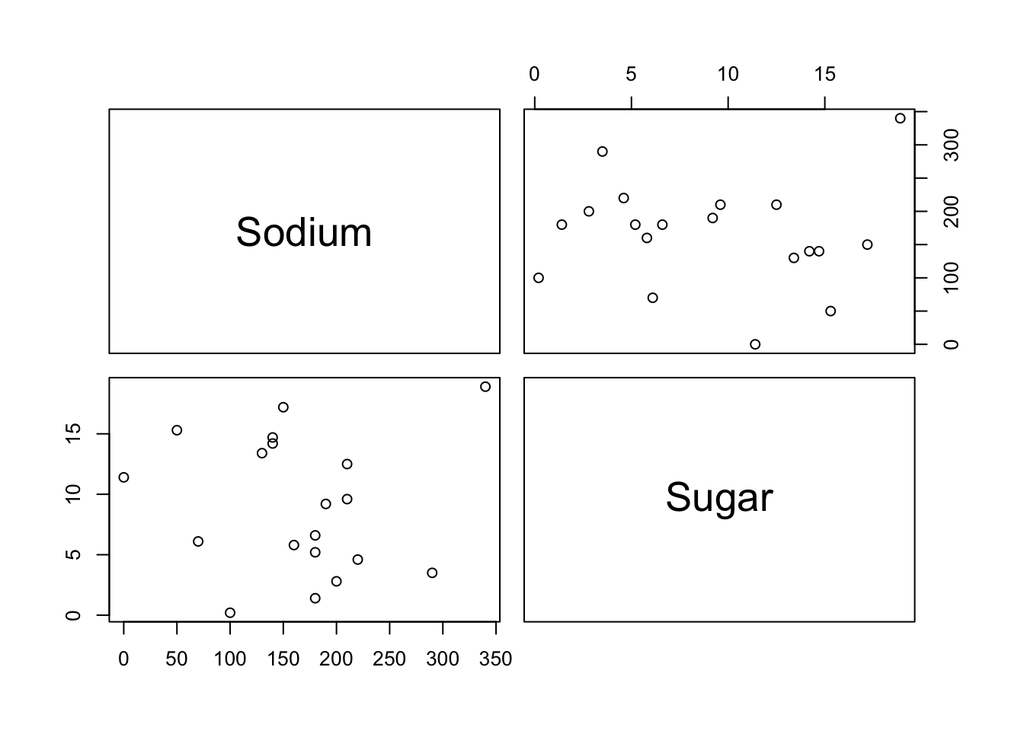

```r
pairs(cereal_new[,1:2])
```

- Export of plots
- ggplot2 https://ggplot2.tidyverse.org/
- Colorbrewer https://colorbrewer2.org/

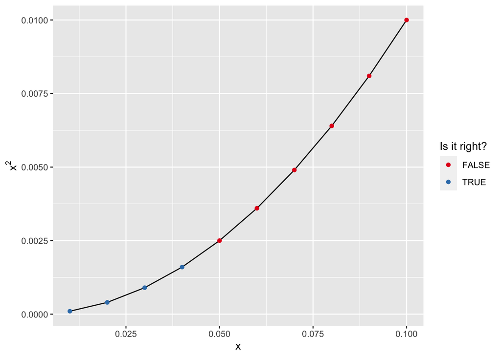

```r
library(ggplot2)
library(RColorBrewer)
ggplot(data = df,
       aes(x = col2, y = col2^2)) +
  geom_line() +
  geom_point(aes(col = col3)) +
  xlab("x") + ylab(expression(x^2)) +
  labs(col = "Is it right?") +
  scale_color_brewer(palette = "Set1") +
  theme_grey()
```

## Programming

- if else

```r
if (3 > 5) {
  print("That's true!")
  } else {
  print("That's false")
  }
```

```
## [1] "That's false"
```

- for, while

```r
for (i in 1:3){
  print(paste("count:", i))
}
```

```
## [1] "count: 1"
## [1] "count: 2"
## [1] "count: 3"
```

```r
j <- 0
while (j < 4){
  print(j)
  j <- j + 1
}
```

```
## [1] 0
## [1] 1
## [1] 2
## [1] 3
```

- functions

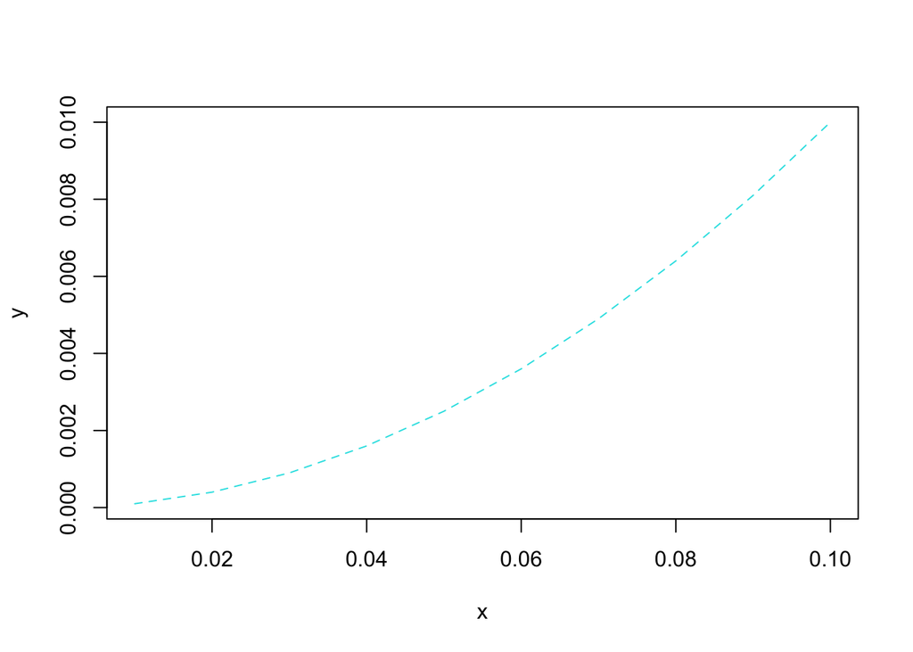

```r
my_plot <- function(x, y, color, linetype) {
  plot(x, y, type = "l", col = color, lty = linetype)
}

my_plot(df$col2, df$col2^2, 5, 2)
```

## R Markdown

- Reporting and reproducible research
- Introduction: https://rmarkdown.rstudio.com/